# Principal component analysis- Digimon data set

When we got our data set there is high probability that we will have to reduce dimensions. I will use Principal Component Analysis to show example how to reduce dimensions of the data but still contain the most information of the previous data. The whole data set has 249 observations and 13 variables. For purpose in this paper I will use 4 variables in terms of psychical strength of the creature.

```r
#Load libraries
library(factoextra)
library(ClusterR)
library(factoextra)
library(corrplot)

#Selecting columns in terms mentioned above
digimons<-read.csv('DigiDB_digimonlist.csv',header=TRUE,sep=",")
digimons<-digimons[,c(8,10,11,13)]

#Quick summary of the data
summary(digimons)
```

```
##     Lv.50.HP       Lv50.Atk        Lv50.Def        Lv50.Spd
##  Min.   : 530   Min.   : 52.0   Min.   : 59.0   Min.   : 61.0
##  1st Qu.: 990   1st Qu.: 89.0   1st Qu.: 93.0   1st Qu.: 92.0
##  Median :1180   Median :119.0   Median :113.0   Median :119.0
##  Mean   :1211   Mean   :124.5   Mean   :116.4   Mean   :120.4
##  3rd Qu.:1480   3rd Qu.:153.0   3rd Qu.:138.0   3rd Qu.:143.0
##  Max.   :2080   Max.   :318.0   Max.   :213.0   Max.   :218.0
```

```r
head(digimons)
```

|  | Lv.50.HP | Lv50.Atk | Lv50.Def | Lv50.Spd |
| --- | --- | --- | --- | --- |
| 1 | 590 | 79 | 69 | 95 |
| 2 | 950 | 76 | 76 | 68 |
| 3 | 870 | 97 | 87 | 75 |
| 4 | 690 | 77 | 95 | 61 |
| 5 | 540 | 54 | 59 | 86 |
| 6 | 940 | 109 | 93 | 76 |

Before using principal component analysis we can check correlation between variables

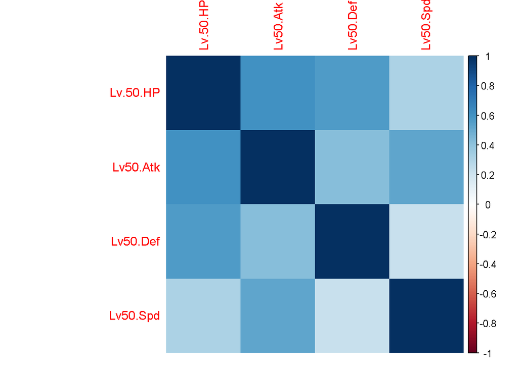

```r
digimons.pca<-prcomp(digimons,center=TRUE, scale.=TRUE)
digimons.pca
```

```
## Standard deviations (1, .., p=4):
## [1] 1.5333831 0.9194689 0.6893201 0.5728446
##
## Rotation (n x k) = (4 x 4):
##                PC1        PC2        PC3        PC4
## Lv.50.HP 0.5426698 -0.3014206  0.4446414 -0.6457159
## Lv50.Atk 0.5543228  0.2037485  0.4420386  0.6751404
## Lv50.Def 0.4708275 -0.5580490 -0.6508777  0.2079927
## Lv50.Spd 0.4201870  0.7457972 -0.4280819 -0.2897850
```

```r
digimons.pca$rotation
```

```
##                PC1        PC2        PC3        PC4
## Lv.50.HP 0.5426698 -0.3014206  0.4446414 -0.6457159
## Lv50.Atk 0.5543228  0.2037485  0.4420386  0.6751404
## Lv50.Def 0.4708275 -0.5580490 -0.6508777  0.2079927
## Lv50.Spd 0.4201870  0.7457972 -0.4280819 -0.2897850
```

```r
#If we consider rotations of PC1 we can say that:
#Lv.50.HP, Lv50.Atk, Lv50.Def and Lv50.Spd are directly related
#Summary of digimons principal compononents
summary(digimons.pca)
```

```
## Importance of components:
##                           PC1    PC2    PC3     PC4
## Standard deviation     1.5334 0.9195 0.6893 0.57284
## Proportion of Variance 0.5878 0.2114 0.1188 0.08204
## Cumulative Proportion  0.5878 0.7992 0.9180 1.00000
```

If we look at Cumulative Proportion we can say that PC1 and PC2 explain almost 80% of total variance of the data

# PCA individual results

Below there are shown the results of Principal Component Analysis for each observation

```r
ind<- get_pca_ind(digimons.pca)
#We see three names
print(ind)
```

```
## Principal Component Analysis Results for individuals
##  ===================================================
##   Name       Description
## 1 "$coord"   "Coordinates for the individuals"
## 2 "$cos2"    "Cos2 for the individuals"
## 3 "$contrib" "contributions of the individuals"
```

```r
#"$coord" Coordinates for the individuals
head(ind$coord)
```

```
##       Dim.1      Dim.2       Dim.3       Dim.4
## 1 -2.607342  0.6129653 0.005452157 0.474962284
## 2 -2.289784 -0.4718031 0.679649302 0.002818077
## 3 -1.916542 -0.3351678 0.459323124 0.480919973
## 4 -2.522039 -0.7169677 0.041786955 0.717583385
## 5 -3.256600  0.5155586 0.015761082 0.219334867
## 6 -1.553514 -0.4276461 0.536340371 0.549785659
```

```r
#"$cos2" it tell us how important is principal component for a given observation
head(ind$cos2)
```

```
##       Dim.1      Dim.2        Dim.3        Dim.4
## 1 0.9187325 0.05077674 4.017258e-06 3.048676e-02
## 2 0.8845191 0.03755258 7.792699e-02 1.339750e-06
## 3 0.8688188 0.02657155 4.990328e-02 5.470640e-02
## 4 0.8605521 0.06954608 2.362408e-04 6.966558e-02
## 5 0.9712300 0.02434161 2.274915e-05 4.405635e-03
## 6 0.7574530 0.05739767 9.028304e-02 9.486631e-02
```

```r
#It show us contribution of a given observation to the principal component
head(ind$contrib)
```

```
##       Dim.1      Dim.2        Dim.3        Dim.4
## 1 1.1611688 0.17848359 2.512438e-05 2.760865e-01
## 2 0.8955469 0.10574215 3.904168e-01 9.719250e-06
## 3 0.6273877 0.05336432 1.783181e-01 2.830562e-01
## 4 1.0864331 0.24418877 1.475843e-03 6.301903e-01
## 5 1.8114580 0.12626491 2.099572e-04 5.887655e-02
## 6 0.4122207 0.08687516 2.431307e-01 3.699251e-01
```

# PCA visualization

Visualizations can help us to choose the number of principal components and verify our decision of taking two principal components.

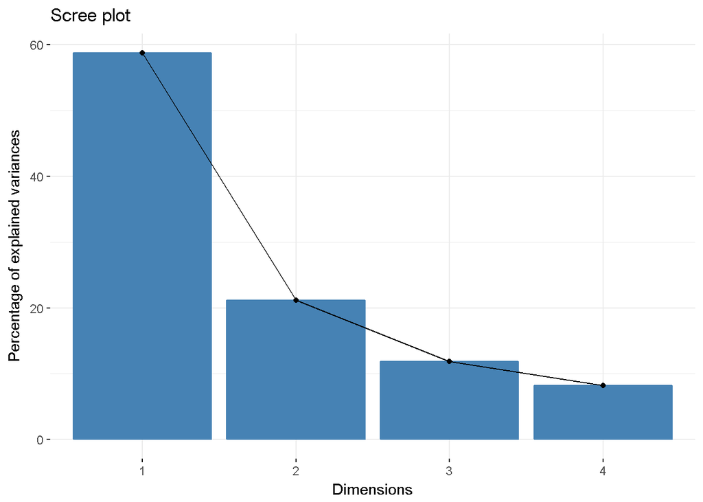

```r
fviz_eig(digimons.pca)
```

Using elbow method and by looking at first two bars we can we see that choosing two principal components was a right idea because they graphically show that almost 80% of total variance of the data is exaplained by them.

# Other Plots

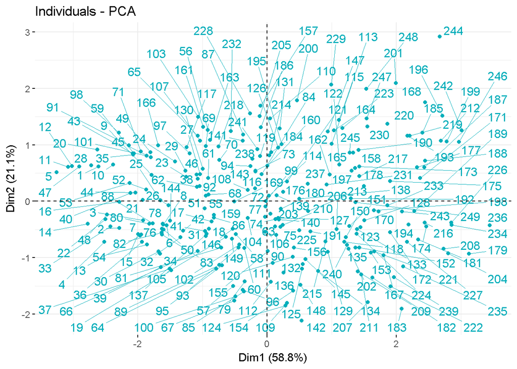

```r
#This plot show us observations on plot with two variables#
fviz_pca_ind(digimons.pca, col.ind = "#00AFBB", repel = TRUE)
```

The plot has principal axes which represent the first and the second PC scores. The observations are plotted on that basis. We can also see the number of the observation.

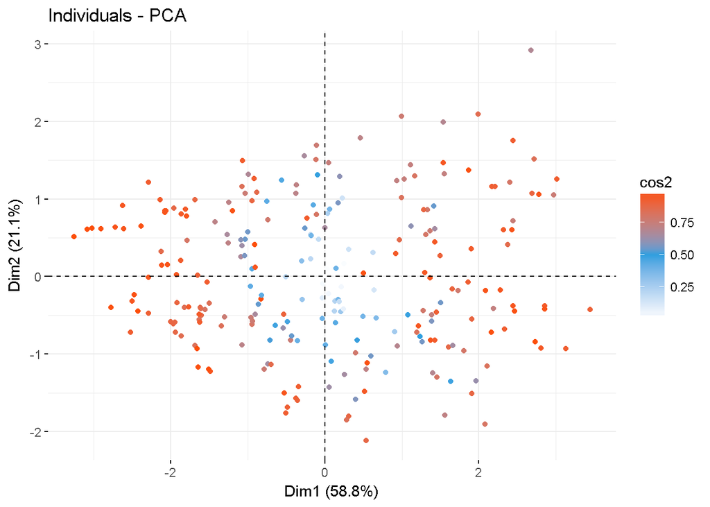

```r
#Plot shows importance of component to the variable
fviz_pca_ind(digimons.pca, col.ind="cos2", geom = "point", gradient.cols = c("white", "#2E9FDF", "#FC4E07" ))
```

Components which has big value of cos2 are contributing a relatively big portion to the total distance and because of that we know the importance of a principal component for a given observation.

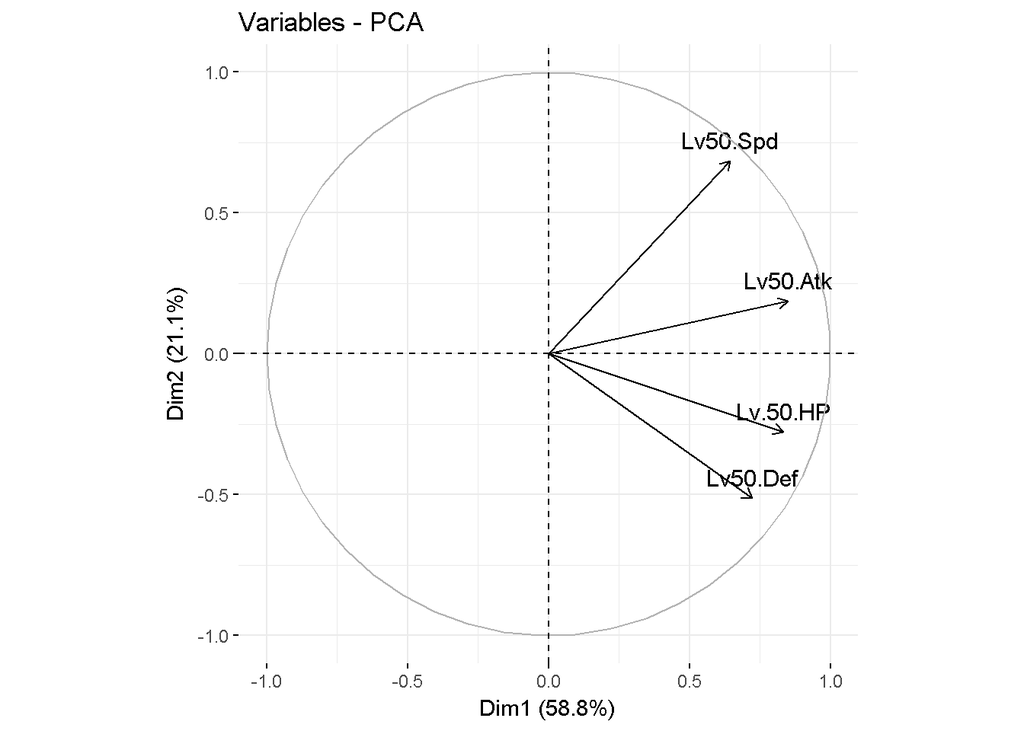

```r
#Correlation circle
#This plot shows us variables correlation
fviz_pca_var(digimons.pca, col.var = "black")
```

This plot shows how variables are correlated. We see that all four variables are positively correlated because they are grouped together.

# Conclusions

Principal Component Analysis help us with dimension reduction in many cases. On this example I wanted to show that even on small data we can provide dimension reduction. In our case we replaced our 4 variables with two principal components which explain almost 80% of total variance of the data We also have to remember that PCA method is very sensitive to the outliers.